# LTOM.01.002 Data Analysis in Community Ecology

## 4.10 First figures

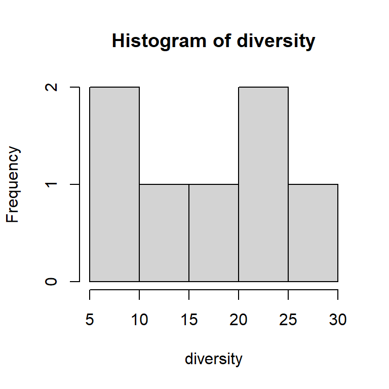

```r
diversity=c(18,27,10,22,25,8,12)
hist(diversity)
```

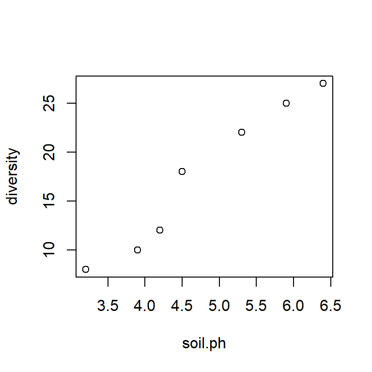

```r
soil.ph=c(4.5,6.4,3.9,5.3,5.9,3.2,4.2)

plot(soil.ph,diversity)
```

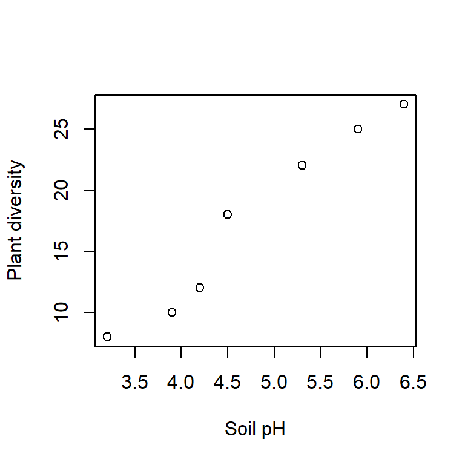

```r
plot(soil.ph,diversity,xlab="Soil pH",ylab="Plant diversity") # axis labels
```

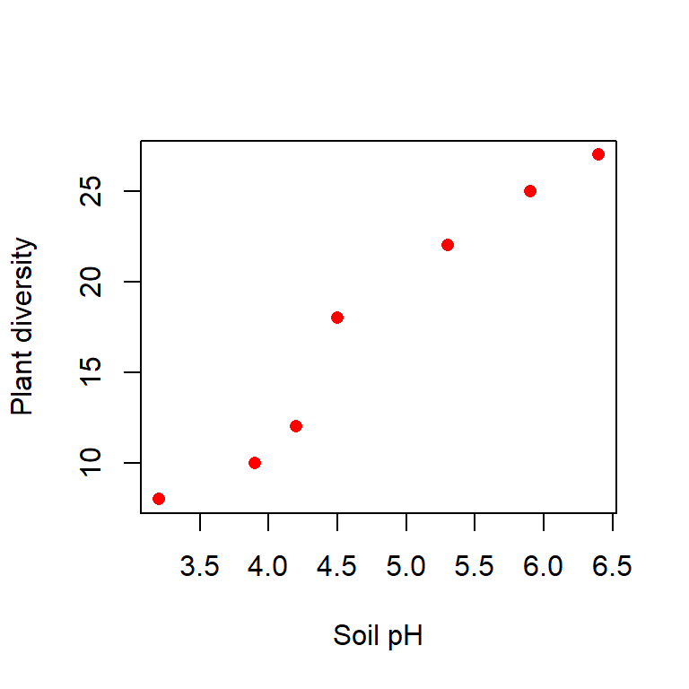

```r
plot(soil.ph,diversity,xlab="Soil pH",ylab="Plant diversity",pch=16,col="red") # symbol code and color
```

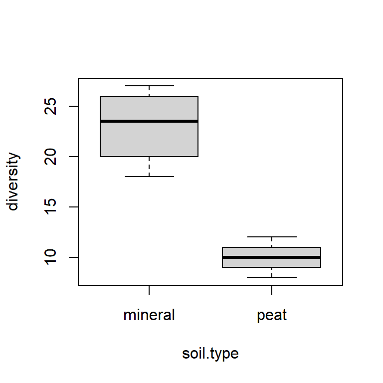

```r
soil.type=c("mineral","mineral","peat","mineral","mineral","peat","peat")

boxplot(diversity~soil.type) # here we give used parameters as formula y ~ x
```

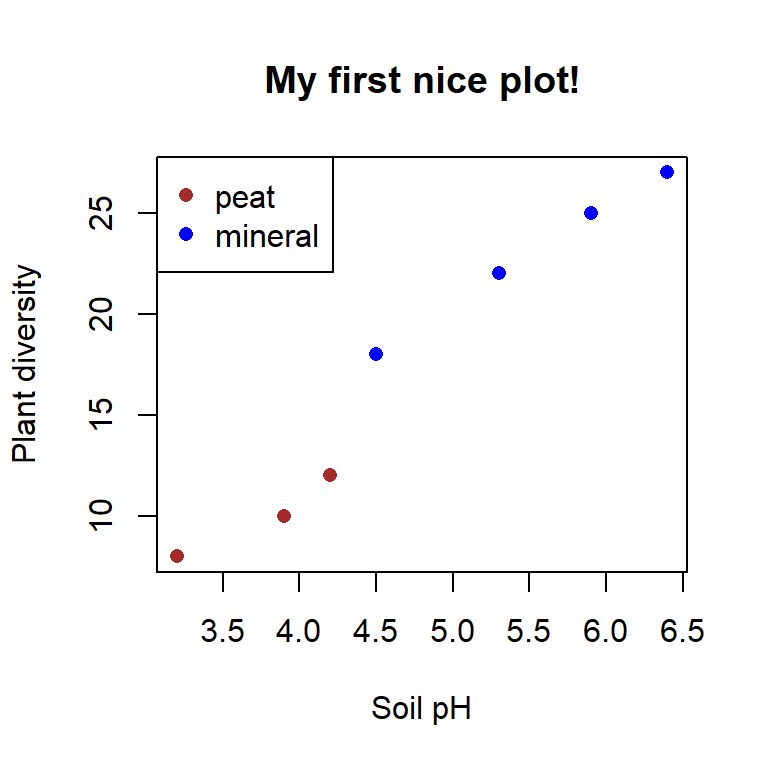

```r
color=rep("blue",length(diversity))
color[soil.type=="peat"]="brown"
plot(diversity
     ~soil.ph,xlab="Soil pH",ylab="Plant diversity",pch=16,col=color) # with formula!
legend("topleft",legend=c("peat","mineral"),pch=16,col=c("brown","blue"))
title("My first nice plot!")
```

> Explore `plot` function and parameters `pch`, `col` and `cex`. Make a plot with different `pch`, `col` and `cex` parameters you like most.

**Answer**

`pch` is defining plot symbols, `col` is changing colors and `cex` is defining size of symbols.

## 4.11 Ending session

There is a function to end session: `q()`, but mostly you can just close the window. If R asks if we should save all objects to memory, I recommend saying No. We rather save later what we need.